# Pauta Tarea 1

Facultad de Economía y Negocios, Universidad de Chile, Chile

2018-10-15 (updated: 2018-10-15)

**Instrucciones**

1. Esta tarea debe ser entregada en grupos de máximo 3 personas.
2. Se debe enviar una carpeta comprimida que contenga: un archivo .Rproj (proyecto en R), un script y un breve informe en R Markdown con sus resultados, incluyendo tablas, gráficos, etc., según corresponda. El formato del infome puede ser word o pdf.
3. El asunto del email con su tarea debe ser “Tarea 2-R Apellido 1 -Apellido 2 -Apellido 3”
4. La fecha de entrega es el Viernes 14 de Septiembre del 2018 hasta las 23:59 hrs al correo del curso: r2018uchile@gmail.com.

> “PowerPoint is like being trapped in the style of early Egyptian flatland cartoons rather than using the more effective tools of Renaissance visual representation.”

> *Edward R. Tufte*, Beautiful Evidence

# Pregunta 1

## Pregunta 1.1

Seleccione dos variables de su interés del *World Development Indicators* para el año 1990 y 2015. Incluya todos los países presentes en la base de datos, excluyendo los agregados regionales. Explique brevemente por qué son relevantes, argumentando a partir de conocimientos de cursos previos y/o trabajos empíricos.

```r
if(!require("pacman")) install.packages("pacman")
p_load("tidyverse", "tidyquant", "WDI", "fBasics", "gridExtra", "grid", "scales",
       "plyr", "extrafont", "zoo")
```

```r
#"NY.GDP.PCAP.PP.CD" -> PIB PPP
#"BN.CAB.XOKA.GD.ZS" -> balance cuenta corriente como porcentaje del pib

wdi_data <- as.tibble(
            WDI(indicator = c("NY.GDP.PCAP.PP.CD", "BN.CAB.XOKA.GD.ZS"),
                country = "all",
                extra = TRUE,
                start = 1990,
                end = 2015)
            )
```

```r
#"NY.GDP.PCAP.PP.CD" -> PIB PPP
#"BN.CAB.XOKA.GD.ZS" -> balance cuenta corriente como porcentaje del pib

wdi_data <- wdi_data %>%
            select(country:region) %>%
            dplyr::rename(pib = NY.GDP.PCAP.PP.CD, cuenta_corriente = BN.CAB.XOKA.GD.ZS) %>%
            dplyr::filter( year %in% c("1990", "2015") & region != "Aggregates") %>%
            na.omit() %>%
            group_by(country, year) %>%
            arrange(year)
```

## Pregunta 1.2

Construya un *data frame* y presente los valores máximos, mínimos, media aritmética, mediana y desviación estándar que permita comparar los valores de cada variable en los años 1990 y 2015.

```r
year_loop <- c(1990, 2015)

list_countries <- list()

for(i in 1:length(year_loop)){

  list_countries[[i]] <- wdi_data %>%
                         dplyr::filter(year == year_loop[i])

     print(knitr::kable(cbind(basicStats(as.matrix(list_countries[[i]][3])),
                        basicStats(as.matrix(list_countries[[i]][4]))),
                        digits = c(1,5)))
}
```

|  | pib | cuenta_corriente |
| --- | --- | --- |
| nobs | 121.0 | 121.00000 |
| NAs | 0.0 | 0.00000 |
| Minimum | 421.4 | -30.23412 |
| Maximum | 27609.0 | 17.60440 |
| 1. Quartile | 1513.7 | -6.13410 |
| 3. Quartile | 9188.6 | -0.23043 |
| Mean | 6595.6 | -3.31438 |
| Median | 3807.7 | -2.81513 |
| Sum | 798071.0 | -401.03940 |
| SE Mean | 632.4 | 0.68527 |
| LCL Mean | 5343.4 | -4.67116 |
| UCL Mean | 7847.8 | -1.95759 |
| Variance | 48397908.1 | 56.82098 |
| Stdev | 6956.9 | 7.53797 |
| Skewness | 1.3 | -0.61068 |
| Kurtosis | 0.7 | 2.42947 |

|  | pib | cuenta_corriente |
| --- | --- | --- |
| nobs | 170.0 | 170.00000 |
| NAs | 0.0 | 0.00000 |
| Minimum | 797.0 | -54.09779 |
| Maximum | 127516.9 | 46.70970 |
| 1. Quartile | 4699.8 | -8.87652 |
| 3. Quartile | 26678.8 | 0.95498 |
| Mean | 19843.5 | -4.09574 |
| Median | 12342.8 | -3.14692 |
| Sum | 3373387.6 | -696.27663 |
| SE Mean | 1662.6 | 0.84871 |
| LCL Mean | 16561.2 | -5.77118 |
| UCL Mean | 23125.7 | -2.42031 |
| Variance | 469947758.3 | 122.45163 |
| Stdev | 21678.3 | 11.06579 |
| Skewness | 2.1 | -0.41979 |
| Kurtosis | 5.2 | 5.24465 |

## Pregunta 1.3

Grafique un boxplot para cada una de las variables que permita la comparación de 1990 y 2015. Interprete.

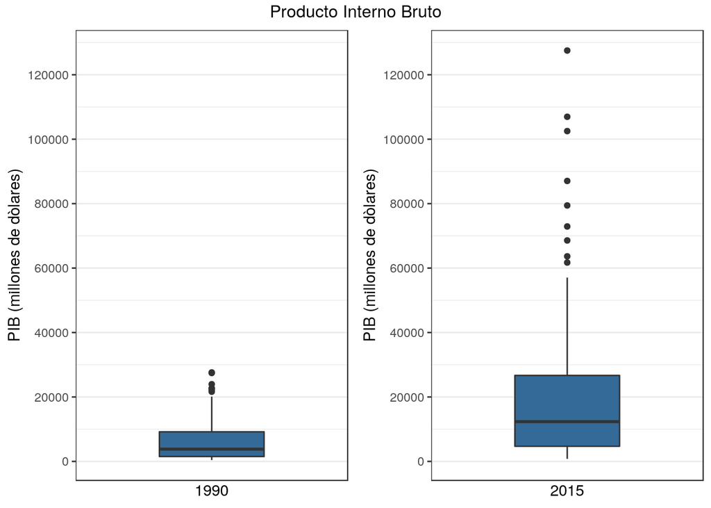

```r
# Grafico para el producto interno bruto 1990 y 2015
ggplot_one <- list_countries[[1]] %>%
              ggplot(mapping = aes(x = year, y = pib, fill=year, group = year)) +
              geom_boxplot(show.legend = FALSE) +
              scale_y_continuous(breaks = pretty_breaks(),
                                 limits = c(min(list_countries[[1]]$pib,
                                                list_countries[[2]]$pib),
                                            max(list_countries[[1]]$pib,
                                                list_countries[[2]]$pib))) +
              ylab("PIB (millones de dòlares)") + xlab("1990") +
              theme_bw() + scale_x_discrete(breaks = NULL)

ggplot_two <- list_countries[[2]] %>%
              ggplot(mapping = aes(x = year, y = pib, fill=year)) +
              geom_boxplot(show.legend = FALSE) +
              scale_y_continuous(breaks = pretty_breaks(),
                                 limits = c(min(list_countries[[1]]$pib,
                                                list_countries[[2]]$pib),
                                            max(list_countries[[1]]$pib,
                                                list_countries[[2]]$pib))) +
              ylab("PIB (millones de dòlares)") + xlab("2015") +
              theme_bw() + scale_x_discrete(breaks = NULL)

grid.arrange(ggplotGrob(ggplot_one), ggplotGrob(ggplot_two), ncol = 2,
             top = "Producto Interno Bruto")
```

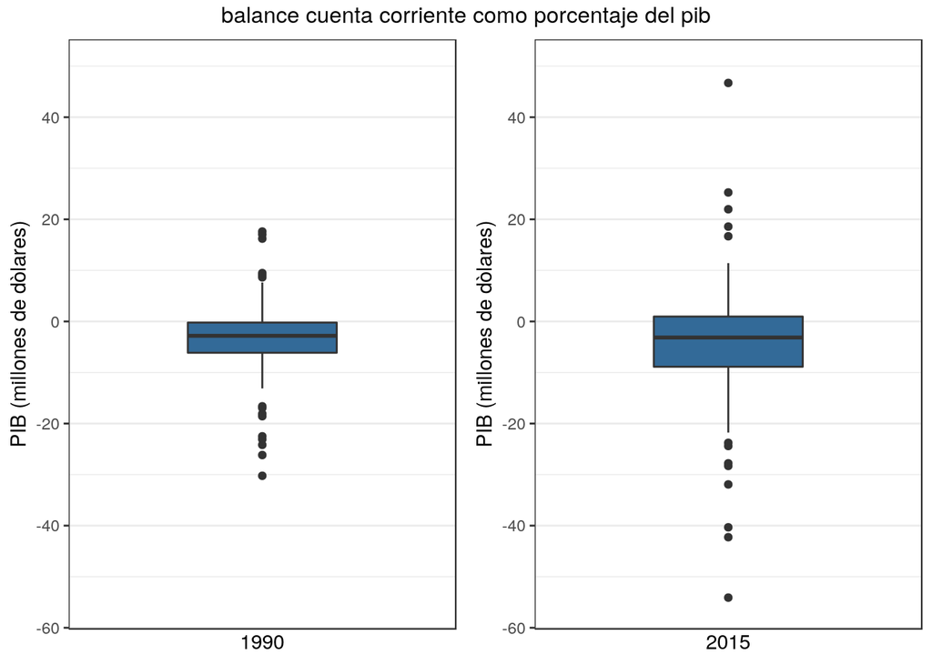

```r
ggplot_one <- list_countries[[1]] %>%
              ggplot(mapping = aes(x = year, y = cuenta_corriente, fill=year,
                                   group = year)) +
              geom_boxplot(show.legend = FALSE) +
              scale_y_continuous(breaks = pretty_breaks(), limits = c(-55, 50)) +
              ylab("PIB (millones de dòlares)") + xlab("1990") + theme_bw() +
              scale_x_discrete(breaks = NULL)

ggplot_two <- list_countries[[2]] %>%
              ggplot(mapping = aes(x = year, y = cuenta_corriente, fill=year)) +
              geom_boxplot(show.legend = FALSE) +
              scale_y_continuous(breaks = pretty_breaks(), limits = c(-55, 50)) +
              ylab("PIB (millones de dòlares)") + xlab("2015") + theme_bw() +
              scale_x_discrete(breaks = NULL)

grid.arrange(ggplotGrob(ggplot_one), ggplotGrob(ggplot_two), ncol = 2,
             top = "balance cuenta corriente como porcentaje del pib")
```

# Pregunta 2

## Pregunta 2.1

Desde *Yahoo Finance* obtenga los precios mensuales de los indices accionarios de los siguientes países desde Enero del 2005 hasta Diciembre del 2017: (a) S&P 500 Estados Unidos (^GSPC), (b) CAC 40 Francia (^FCHI), (c) DAX Alemania (^GDAXI) y FTSE 100 Reino Unido (^FTSE).

1. Genere un gráfico de densidad para el retorno[^1] de cada índice accionario.

   ```r
   tickers <- c("^GDAXI", "^FTSE")
   ```

   ```r
   data_activos <- tq_get(tickers,
                   get = "stock.prices",
                   from = "2005-01-01",
                   to  = "2018-01-01",
                   periodicity = "monthly")
   ```

   ```r
   retornos_activos <- data_activos %>%
                       group_by(symbol) %>%
                       tq_transmute(select = close,
                         mutate_fun = periodReturn,
                         period = "daily",
                         type = "log",
                         col_rename = "retornos.diarios")
   ```

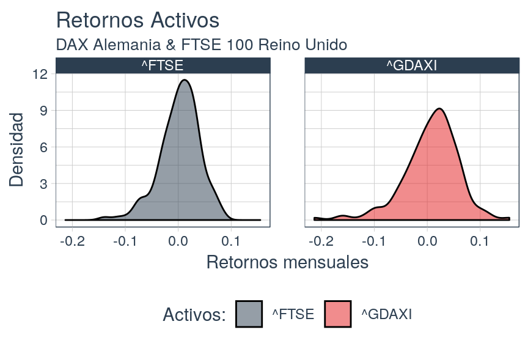

   ```r
   retornos_activos %>%
            ggplot(mapping = aes(x = retornos.diarios, fill = symbol))+
            geom_density(alpha = 0.5) +
                labs(title = "Retornos Activos",
                     subtitle = "DAX Alemania & FTSE 100 Reino Unido",
                     x = "Retornos mensuales", y = "Densidad") +
            theme_tq() +
            scale_fill_tq() +
            facet_wrap(~ symbol, ncol = 2) +
            guides(fill=guide_legend(title="Activos:"))
   ```

2. Use un *Q-Q plot* para comparar la distribución de los retornos de cada índice accionario con la distribución normal. Comente.

[figure not shown]

   ```r
   retornos_activos %>%
            ggplot(mapping = aes(sample = retornos.diarios, fill = symbol))+
            stat_qq() +
            labs(title = "QQ plots Retornos Activos",
              subtitle = "Oracle (ORCL), Intel (IT), Nvidia (NVDA) y Netflix (NFLX)",
              x = "Retornos mensuales", y = "Densidad") +
            theme_tq() +
            scale_fill_tq() +
            facet_wrap(~ symbol, ncol = 2) +
            guides(fill=guide_legend(title="Activos:"))
   ```

## Pregunta 2.2

El análisis técnico consiste en detectar determinados patrones de comportamiento de los precios en el pasado, con la esperanza de que dicho patrones vuelvan a repetirse y poder así aprovecharnos de ello. A partir de lo anterior se le solicita:

1. Construir un *Candlestick* para cada índice accionario y determine patrones. Comente.

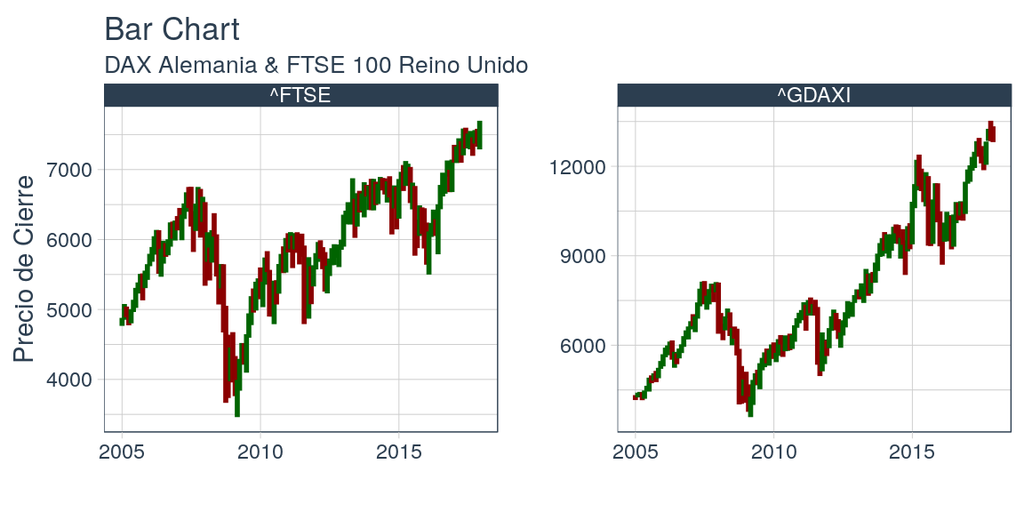

   ```r
   data_activos %>%
        ggplot(aes(x = date, y = close, group = symbol)) +
        geom_barchart(aes(open = open, high = high, low = low, close = close),
          color_up = "darkgreen", color_down = "darkred", size = 1) +
        labs(title = "Bar Chart",
          subtitle = "DAX Alemania & FTSE 100 Reino Unido",
          y = "Precio de Cierre", x = "") +
       #  coord_x_date(xlim = c(end - weeks(6), end)) +
        facet_wrap(~ symbol, ncol = 2, scale = "free_y") +
        theme_tq()
   ```

2. Construir las *bandas de bollinger* para cada índice accionario. Comente.

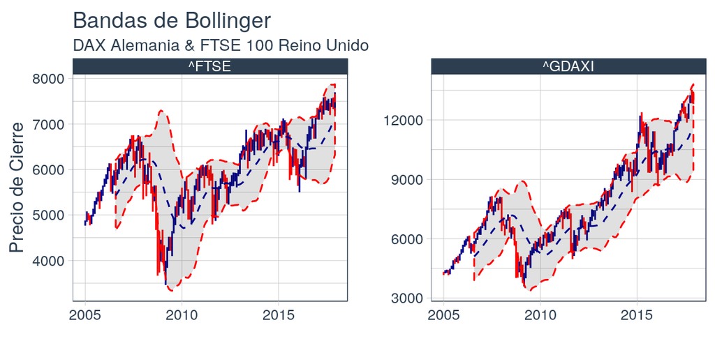

   ```r
   data_activos %>%
        ggplot(aes(x=date, y=close, open = open,
                   high = high, low = low, close = close)) +
         geom_candlestick() +
         geom_bbands(ma_fun = SMA, sd = 2, n = 20)  +
         labs(title = "Bandas de Bollinger ",
              subtitle = "DAX Alemania & FTSE 100 Reino Unido",
              y = "Precio de Cierre", x = "") +
       #  coord_x_date(xlim = c(end - weeks(6), end)) +
        facet_wrap(~ symbol, ncol = 2, scale = "free_y") +
        theme_tq()
   ```

## Pregunta 2.3

Finalmente descargue desde *Yahoo Finance* el índice de volatilidad VIX[^2] desde 1990 hasta la fecha con periodicidad mensual, posteriormente gráfique identificando los periodos de recesiones[^3]. ¿Qué puede observa?¿es útil este índice?.

```r
data_vix <- tq_get("VIXCLS",
                   get = "economic.data",
                   from = "1990-01-01",
                   to  = "2018-01-01",
                   periodicity = "daily") %>%
                   na.omit()
```

```r
recessions_df <- read.table(textConnection("Peak, Trough
                                           1990-07-01, 1991-03-01
                                           2001-03-01, 2001-11-01
                                           2007-12-01, 2009-06-01"),
                 sep=',',colClasses=c('Date', 'Date'), header=TRUE)

recessions_trim <-  subset(recessions_df, Peak >= min(index(data_vix$date)))
```

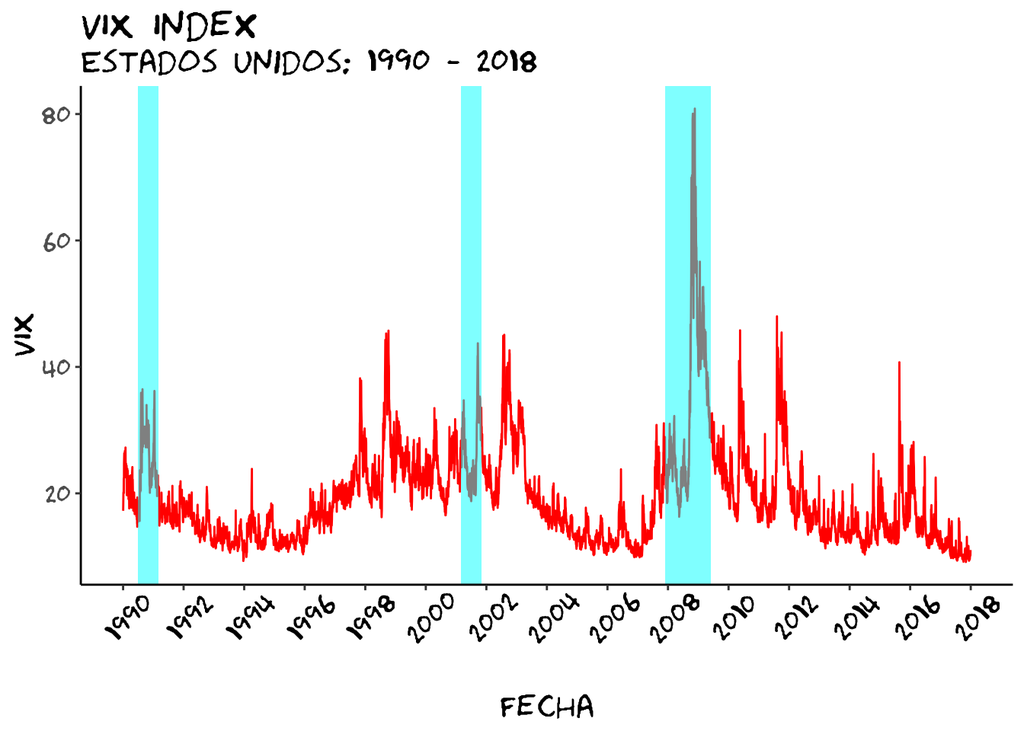

```r
data_vix %>%
  ggplot() + geom_line(aes(x = date, y = price), size = 0.5, color = "red") +
  theme_xkcd + geom_rect(data=recessions_trim, aes(xmin = Peak,
                                                   xmax = Trough, ymin=-Inf, ymax=+Inf),
                         fill='cyan', alpha=0.5) +
  xlab("Fecha") + ylab("VIX") + labs(title = "VIX Index",
                                     subtitle = "Estados Unidos: 1990 - 2018") +
  scale_x_date(breaks = pretty_breaks(n = 12)) +
  theme(axis.text.x = element_text(size=14, angle=45,
                                   margin = margin(t = 10, r = 20, b = 10, l = 10)))
```

[^1]: La fórmula para calcular (log) retornos es: $r_t = log(1 + R_t) = log(\frac{P_t}{P_{t-1}}) = p_t - p_{t-1}$
[^2]: Chicago Board Options Exchange Market Volatility Index.
[^3]: Los periodos de recesiones se pueden descargar desde FRED (Federal Reserve Economic Data).

**Disclaimer** : La información contenida en esta página está bajo una [Licencia Creative Commons Atribución-NoComercial-SinDerivadas 4.0 Internacional](http://creativecommons.org/licenses/by-nc-nd/4.0/) y fue construida bajo mi rol como ayudante (*Teacher Assistant*) de la Catedra Topicos en economía y negocios utilizando R ( *R for economy and business* ).